# Tugas Praktikum 4 MPDW

Muhammad Khayruhanif

2026-09-10

# Proses MA(2)

- Bangkitkan model MA(2) dengan 𝜃1 = 0.4 dan 𝜃2 = 0.6 sebanyak 300 data (Manual dan dengan arima.sim)
- Buat plot time series, plot ACF, plot PACF dan plot EACF. Idenifikasi apakah data tersebut stasioner
- Buat scatterplot antara 𝑌𝑡 dengan 𝑌𝑡−1, 𝑌𝑡 dengan 𝑌𝑡−2 serta 𝑌𝑡 dengan 𝑌𝑡−3
- Hitung autokorelasi masing masing baik dari data bangkitan maupun secara teoritis

## Bangkitkan dengan arima.sim

```r
ma <- arima.sim(list(order=c(0,0,2), ma=c(0.4, 0.6)), n=300)
ma
```

```
## Time Series:
## Start = 1
## End = 300
## Frequency = 1
##   [1]  0.25233765 -0.77002544 -1.54683988 -1.54466431 -0.18905232 -0.47416465
##   [7] -1.00715729 -2.27760836 -1.27905739 -1.38987010  0.13542587  0.14026488
##  [13]  1.11210182  1.54723657  2.85726363  2.02686181  0.47715396 -0.80616364
##  [19] -1.26582542  0.24899677 -0.46379939 -0.96434648 -2.36990065 -0.76118905
##  [25] -1.40846952  0.84903323  1.21162883  1.78473309  1.37746110  0.47835137
##  [31]  1.29955180  0.50760209 -0.02617316  2.91723298  1.11172904  2.07924808
##  [37] -0.02537765 -1.57830447  0.12464105 -1.71447679  0.43084303  0.47670727
##  [43]  0.96152018  0.06220266  1.93957768  1.49616735  2.02712162  0.81391178
##  [49] -0.35785269 -0.58369961 -0.29475442 -0.20700459 -0.58252323 -1.28479196
##  [55] -0.97777084 -0.97591865  0.80360749  0.87890121 -0.74000150 -0.65573061
##  [61] -0.19167629  0.30677615  0.24679751 -1.27913454  0.03260567  1.47170061
```

[output cut: 39 more lines]

## Plot time series

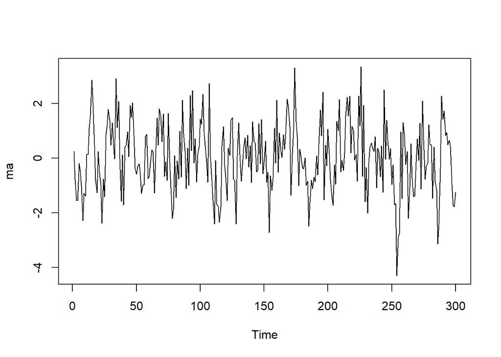

```r
ts.plot(ma)
```

## Plot ACF

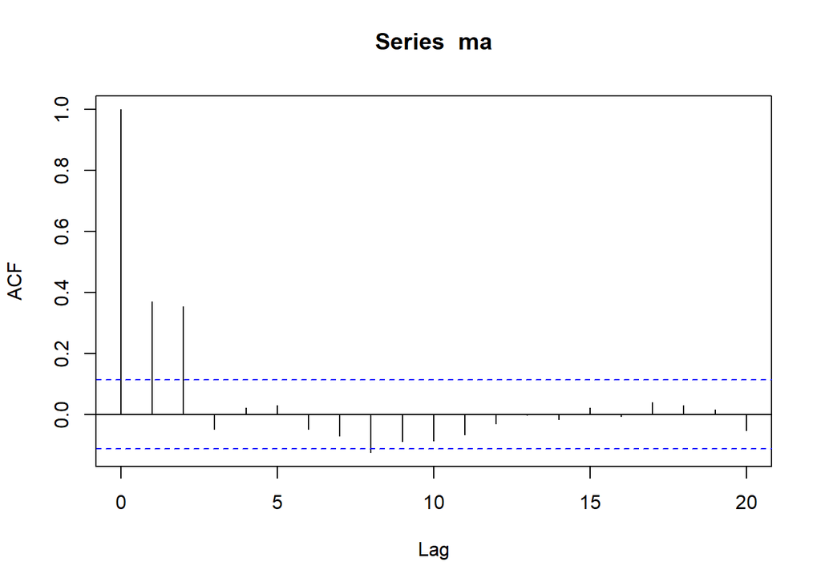

```r
acf(ma,lag.max = 20)
```

## Plot PACF

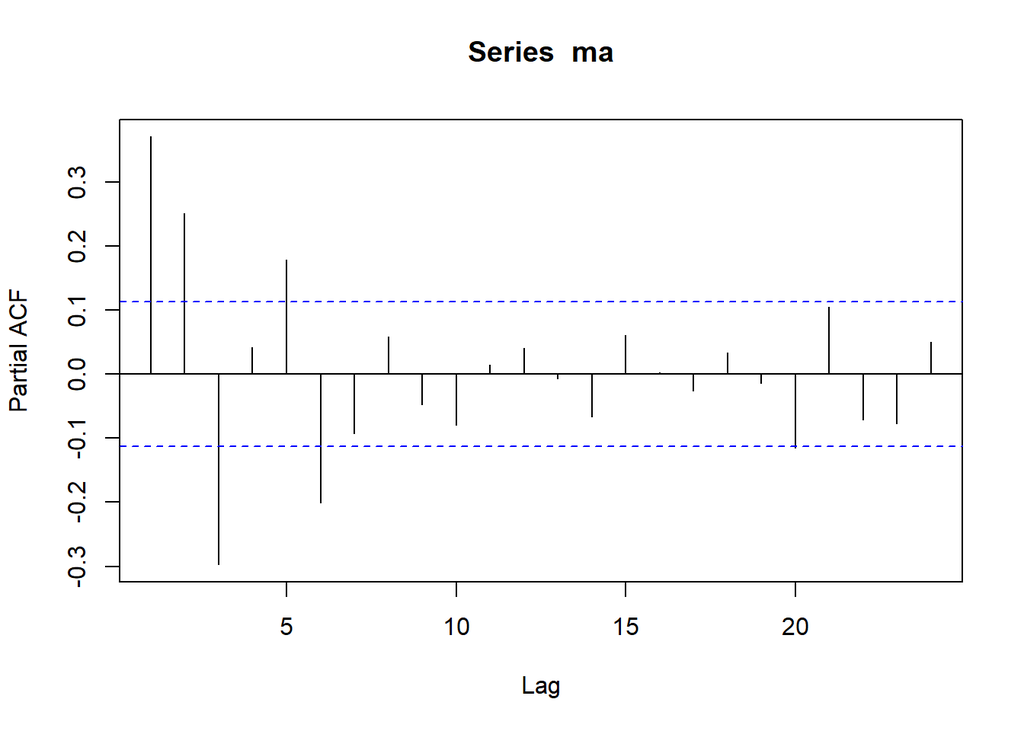

```r
pacf(ma)
```

## Plot EACF

```r
TSA::eacf(ma)
```

```
## AR/MA
##   0 1 2 3 4 5 6 7 8 9 10 11 12 13
## 0 x x o o o o o x o o o  o  o  o
## 1 x x o o o o o o o o o  o  o  o
## 2 x x x o o o o o o o o  o  o  o
## 3 x x o o o o o o o o o  o  o  o
## 4 x x x o x x o o o o o  o  o  o
## 5 x x x o x x x o o o o  o  o  o
## 6 x x x o o x o x o o o  o  o  o
## 7 x o x x o x o x o o o  o  o  o
```

## Scatter plot antar lag

```r
yt_ma <- ma[-1]
yt_ma
```

```
##   [1] -0.77002544 -1.54683988 -1.54466431 -0.18905232 -0.47416465 -1.00715729
##   [7] -2.27760836 -1.27905739 -1.38987010  0.13542587  0.14026488  1.11210182
##  [13]  1.54723657  2.85726363  2.02686181  0.47715396 -0.80616364 -1.26582542
##  [19]  0.24899677 -0.46379939 -0.96434648 -2.36990065 -0.76118905 -1.40846952
##  [25]  0.84903323  1.21162883  1.78473309  1.37746110  0.47835137  1.29955180
##  [31]  0.50760209 -0.02617316  2.91723298  1.11172904  2.07924808 -0.02537765
##  [37] -1.57830447  0.12464105 -1.71447679  0.43084303  0.47670727  0.96152018
##  [43]  0.06220266  1.93957768  1.49616735  2.02712162  0.81391178 -0.35785269
##  [49] -0.58369961 -0.29475442 -0.20700459 -0.58252323 -1.28479196 -0.97777084
##  [55] -0.97591865  0.80360749  0.87890121 -0.74000150 -0.65573061 -0.19167629
##  [61]  0.30677615  0.24679751 -1.27913454  0.03260567  1.47170061  0.48092373
##  [67]  1.81568113  1.51659212  0.60755123  1.61540337 -0.66534301 -0.13329170
##  [73] -0.81928381  1.65058888 -0.16590234 -1.06613001 -2.19396123 -1.87104982
##  [79]  0.10193840 -1.43554099 -0.08829693 -0.75390594  0.99422920 -0.69077333
##  [85]  2.12628834  0.90017837  0.26511524 -1.10776917  0.36523672 -0.99199307
```

[output cut: 35 more lines]

```r
yt_1_ma <- ma[-300]
yt_1_ma
```

```
##   [1]  0.25233765 -0.77002544 -1.54683988 -1.54466431 -0.18905232 -0.47416465
##   [7] -1.00715729 -2.27760836 -1.27905739 -1.38987010  0.13542587  0.14026488
##  [13]  1.11210182  1.54723657  2.85726363  2.02686181  0.47715396 -0.80616364
##  [19] -1.26582542  0.24899677 -0.46379939 -0.96434648 -2.36990065 -0.76118905
##  [25] -1.40846952  0.84903323  1.21162883  1.78473309  1.37746110  0.47835137
##  [31]  1.29955180  0.50760209 -0.02617316  2.91723298  1.11172904  2.07924808
##  [37] -0.02537765 -1.57830447  0.12464105 -1.71447679  0.43084303  0.47670727
##  [43]  0.96152018  0.06220266  1.93957768  1.49616735  2.02712162  0.81391178
##  [49] -0.35785269 -0.58369961 -0.29475442 -0.20700459 -0.58252323 -1.28479196
##  [55] -0.97777084 -0.97591865  0.80360749  0.87890121 -0.74000150 -0.65573061
##  [61] -0.19167629  0.30677615  0.24679751 -1.27913454  0.03260567  1.47170061
##  [67]  0.48092373  1.81568113  1.51659212  0.60755123  1.61540337 -0.66534301
##  [73] -0.13329170 -0.81928381  1.65058888 -0.16590234 -1.06613001 -2.19396123
##  [79] -1.87104982  0.10193840 -1.43554099 -0.08829693 -0.75390594  0.99422920
##  [85] -0.69077333  2.12628834  0.90017837  0.26511524 -1.10776917  0.36523672
```

[output cut: 35 more lines]

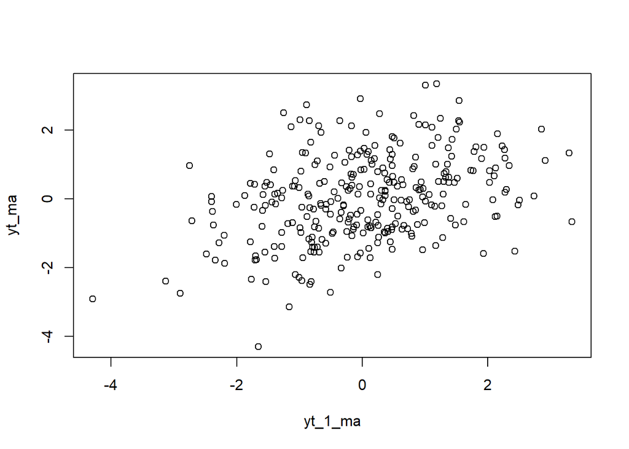

```r
plot(y=yt_ma,x=yt_1_ma)
```

```r
cor(yt_ma,yt_1_ma)
```

```
## [1] 0.3714988
```

```r
yt_ma2 <- ma[-c(1,2)]
yt_ma2
```

```
##   [1] -1.54683988 -1.54466431 -0.18905232 -0.47416465 -1.00715729 -2.27760836
##   [7] -1.27905739 -1.38987010  0.13542587  0.14026488  1.11210182  1.54723657
##  [13]  2.85726363  2.02686181  0.47715396 -0.80616364 -1.26582542  0.24899677
##  [19] -0.46379939 -0.96434648 -2.36990065 -0.76118905 -1.40846952  0.84903323
##  [25]  1.21162883  1.78473309  1.37746110  0.47835137  1.29955180  0.50760209
##  [31] -0.02617316  2.91723298  1.11172904  2.07924808 -0.02537765 -1.57830447
##  [37]  0.12464105 -1.71447679  0.43084303  0.47670727  0.96152018  0.06220266
##  [43]  1.93957768  1.49616735  2.02712162  0.81391178 -0.35785269 -0.58369961
##  [49] -0.29475442 -0.20700459 -0.58252323 -1.28479196 -0.97777084 -0.97591865
##  [55]  0.80360749  0.87890121 -0.74000150 -0.65573061 -0.19167629  0.30677615
##  [61]  0.24679751 -1.27913454  0.03260567  1.47170061  0.48092373  1.81568113
##  [67]  1.51659212  0.60755123  1.61540337 -0.66534301 -0.13329170 -0.81928381
##  [73]  1.65058888 -0.16590234 -1.06613001 -2.19396123 -1.87104982  0.10193840
##  [79] -1.43554099 -0.08829693 -0.75390594  0.99422920 -0.69077333  2.12628834
##  [85]  0.90017837  0.26511524 -1.10776917  0.36523672 -0.99199307  2.29664101
```

[output cut: 35 more lines]

```r
yt_2_ma <- ma[-c(299,300)]
yt_2_ma
```

```
##   [1]  0.25233765 -0.77002544 -1.54683988 -1.54466431 -0.18905232 -0.47416465
##   [7] -1.00715729 -2.27760836 -1.27905739 -1.38987010  0.13542587  0.14026488
##  [13]  1.11210182  1.54723657  2.85726363  2.02686181  0.47715396 -0.80616364
##  [19] -1.26582542  0.24899677 -0.46379939 -0.96434648 -2.36990065 -0.76118905
##  [25] -1.40846952  0.84903323  1.21162883  1.78473309  1.37746110  0.47835137
##  [31]  1.29955180  0.50760209 -0.02617316  2.91723298  1.11172904  2.07924808
##  [37] -0.02537765 -1.57830447  0.12464105 -1.71447679  0.43084303  0.47670727
##  [43]  0.96152018  0.06220266  1.93957768  1.49616735  2.02712162  0.81391178
##  [49] -0.35785269 -0.58369961 -0.29475442 -0.20700459 -0.58252323 -1.28479196
##  [55] -0.97777084 -0.97591865  0.80360749  0.87890121 -0.74000150 -0.65573061
##  [61] -0.19167629  0.30677615  0.24679751 -1.27913454  0.03260567  1.47170061
##  [67]  0.48092373  1.81568113  1.51659212  0.60755123  1.61540337 -0.66534301
##  [73] -0.13329170 -0.81928381  1.65058888 -0.16590234 -1.06613001 -2.19396123
##  [79] -1.87104982  0.10193840 -1.43554099 -0.08829693 -0.75390594  0.99422920
##  [85] -0.69077333  2.12628834  0.90017837  0.26511524 -1.10776917  0.36523672
```

[output cut: 35 more lines]

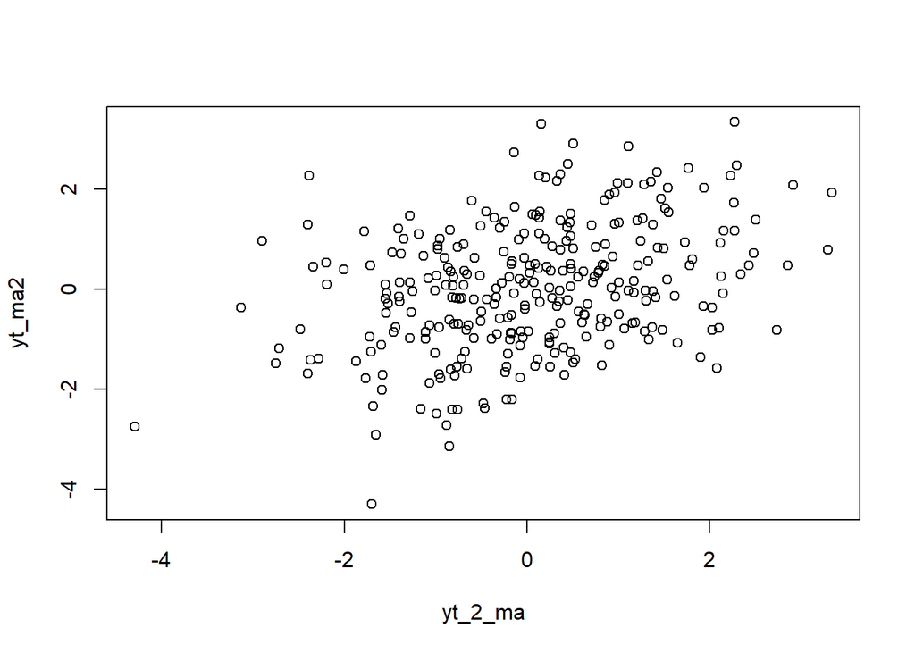

```r
plot(y=yt_ma2,x=yt_2_ma)
```

```r
cor(yt_ma2,yt_2_ma)
```

```
## [1] 0.355939
```

Secara teoritis, fungsi autokorelasi ($\rho_k$) untuk proses $MA(2)$ dirumuskan sebagai:

$$\rho_k =
\begin{cases}
1, & k = 0 \\
\frac{\theta_1 + \theta_1 \theta_2}{1 + \theta_1^2 + \theta_2^2}, &
k = 1 \\
\frac{\theta_2}{1 + \theta_1^2 + \theta_2^2}, & k = 2 \\
0, & k > 2
\end{cases}$$

Dengan substitusi nilai parameter $\theta_1 = 0.4$ dan $\theta_2 = 0.6$:

$$\rho_1 = \frac{0.4 + (0.4)(0.6)}{1 +
0.4^2 + 0.6^2} = \frac{0.64}{1.52} \approx 0.4210526$$

$$\rho_2 = \frac{0.6}{1 + 0.4^2 + 0.6^2} =
\frac{0.6}{1.52} \approx 0.3947368$$

$$\rho_k = 0 \quad \text{untuk } k \ge
3$$

Nilai autokorelasi dari hasil simulasi data (`cor()`) terpotong (*cut off*) setelah *lag* 2, mendekati perhitungan nilai teoritis tersebut.

# Proses AR(2)

- Bangkitkan model AR(2) dengan 𝜙1 = 0.5 dan 𝜙2 = 0.2 sebanya 300 data (Manual dan dengan arima.sim)
- Buat plot time series, plot ACF, plot PACF dan plot EACF. Idenifikasi apakah data tersebut stasioner
- Buat scatterplot antara 𝑌𝑡 dengan 𝑌𝑡−1, 𝑌𝑡 dengan 𝑌𝑡−2 serta 𝑌𝑡 dengan 𝑌𝑡−3
- Hitung autokorelasi masing masing baik dari data bangkitan maupun secara teoritis

## Bangkitkan dengan arima.sim

```r
set.seed(1234)
```

```r
ar <- arima.sim(list(order=c(2,0,0), ar=c(0.5, 0.2)), n=300)
ar
```

```
## Time Series:
## Start = 1
## End = 300
## Frequency = 1
##   [1] -1.7066325607 -0.4040571790 -1.5670108246 -0.8794551485 -1.6890783403
##   [6]  0.0818673463 -0.7724750738 -1.0793041051 -1.1954051279 -2.4426568541
##  [11] -2.6280287147 -3.9825853771 -3.8578916236 -3.0197567460 -2.7473542381
##  [16] -0.5281322030 -1.8821796728 -1.9020809107 -1.6080993919 -2.1788059544
##  [21] -2.3795371734 -2.7328479702 -3.0943173054 -2.6175563658 -2.4244916012
##  [26] -3.5417883306 -2.8378684102 -3.2361814957 -3.2006264394 -2.4098590424
##  [31] -1.2819989901  0.5248461693 -0.7673301373  1.3272137941 -0.6476676781
##  [36]  0.5981973841  2.7185562271  1.4441572006  0.5961562661  0.5793048174
##  [41]  2.1859681101  0.0702372818  1.8401394423  2.2636819683  1.8363416698
##  [46]  1.3778000670  0.6006996293  0.2093858952  0.8731194410  2.5487077608
##  [51]  1.2955793561 -0.2331697165 -0.5810507641 -0.0788975632 -0.4727180494
```

[output cut: 49 more lines]

## Plot time series

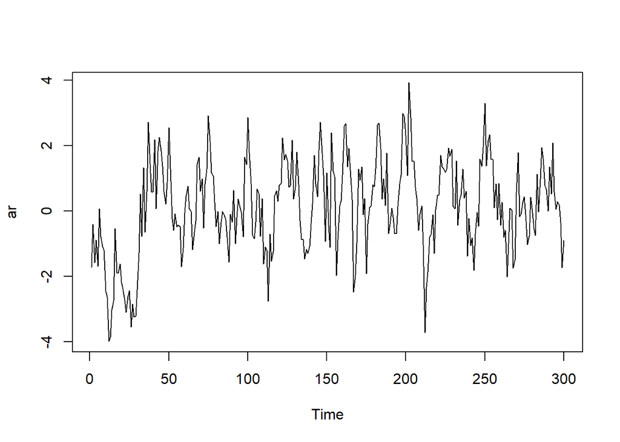

```r
ts.plot(ar)
```

## Plot ACF

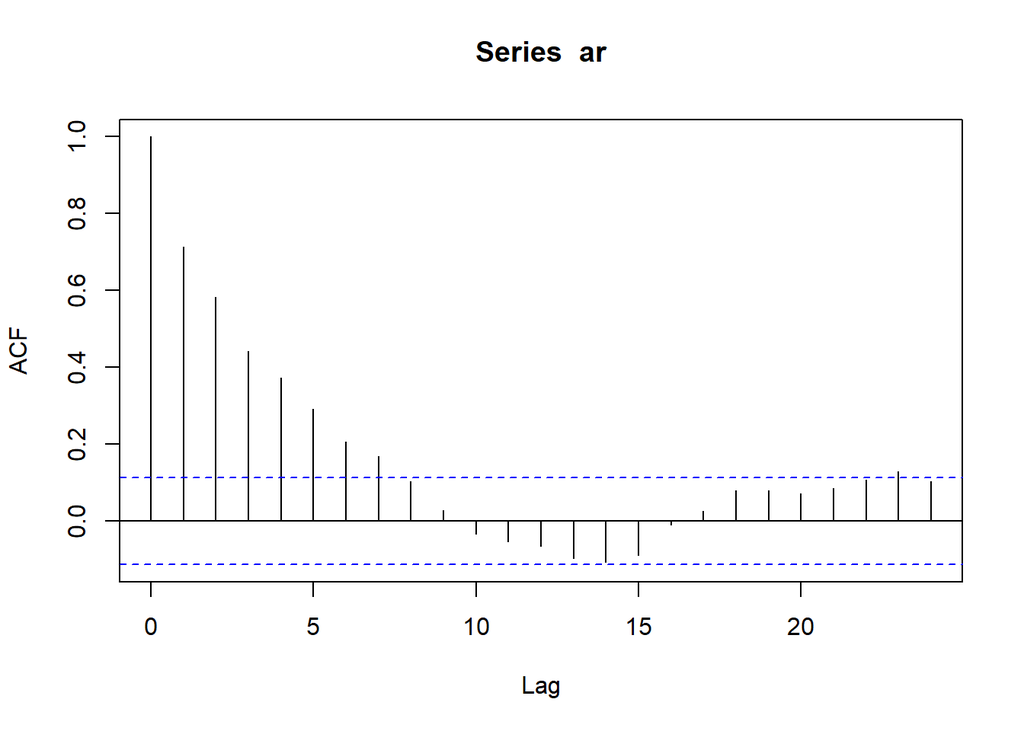

```r
acf(ar)
```

## Plot PACF

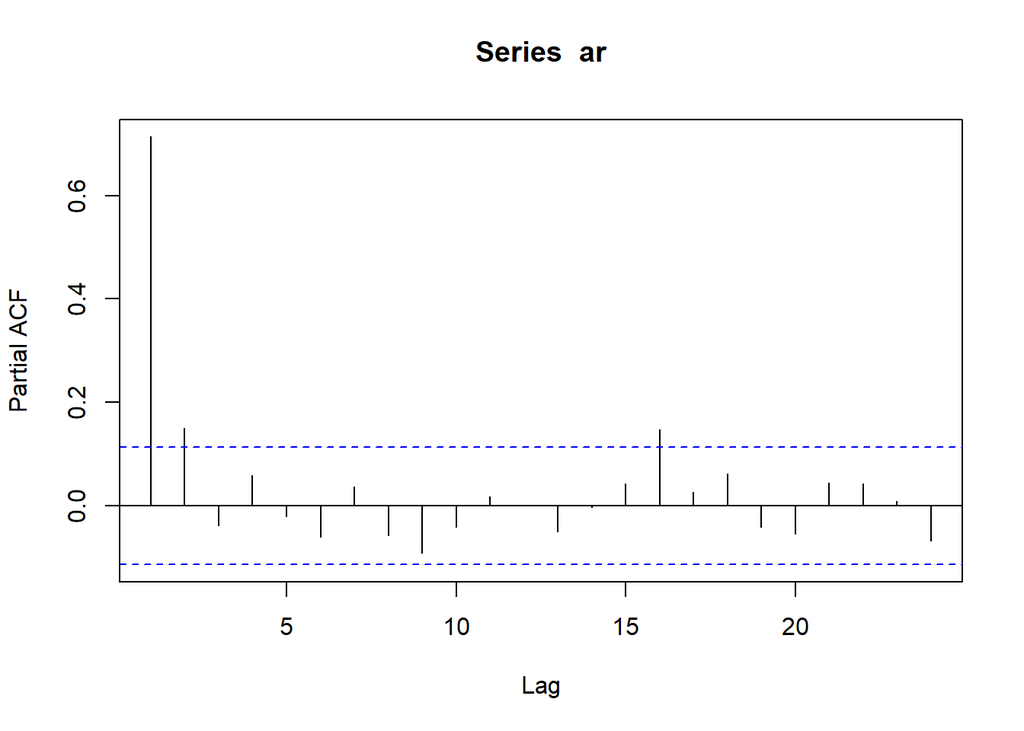

```r
pacf(ar)
```

## Plot EACF

```r
TSA::eacf(ar)
```

```
## AR/MA
##   0 1 2 3 4 5 6 7 8 9 10 11 12 13
## 0 x x x x x x x o o o o  o  o  o
## 1 x o o o o o o o o o o  o  o  o
## 2 x o o o o o o o o o o  o  o  o
## 3 x x o o o o o o o o o  o  o  o
## 4 x x o o o o o o o o o  o  o  o
## 5 x x x o o o o o o o o  o  o  o
## 6 x x x o o o o o o o o  o  o  o
## 7 x x x o x x o o o o o  o  o  o
```

## Scatterplot dan korelasi antara Y_t dengan Y_{t-1}

```r
yt_ar <- ar[-1]
yt_ar
```

```
##   [1] -0.4040571790 -1.5670108246 -0.8794551485 -1.6890783403  0.0818673463
##   [6] -0.7724750738 -1.0793041051 -1.1954051279 -2.4426568541 -2.6280287147
##  [11] -3.9825853771 -3.8578916236 -3.0197567460 -2.7473542381 -0.5281322030
##  [16] -1.8821796728 -1.9020809107 -1.6080993919 -2.1788059544 -2.3795371734
##  [21] -2.7328479702 -3.0943173054 -2.6175563658 -2.4244916012 -3.5417883306
##  [26] -2.8378684102 -3.2361814957 -3.2006264394 -2.4098590424 -1.2819989901
##  [31]  0.5248461693 -0.7673301373  1.3272137941 -0.6476676781  0.5981973841
##  [36]  2.7185562271  1.4441572006  0.5961562661  0.5793048174  2.1859681101
##  [41]  0.0702372818  1.8401394423  2.2636819683  1.8363416698  1.3778000670
##  [46]  0.6006996293  0.2093858952  0.8731194410  2.5487077608  1.2955793561
##  [51] -0.2331697165 -0.5810507641 -0.0788975632 -0.4727180494 -0.4299284950
##  [56] -0.4795019342 -1.6980385520 -1.1187068333 -0.0487288699  0.4495029101
##  [61]  0.7650030321  0.0696701226 -0.0037581027 -1.1824729064 -0.6451468925
##  [66] -0.3038720265  1.4249986155  1.6532381548  0.6160353575  0.9942156067
##  [71] -0.5142931687  0.8199001639  1.2800082016  2.9251012390  2.1330757942
```

[output cut: 45 more lines]

```r
yt_1_ar <- ar[-300]
yt_1_ar
```

```
##   [1] -1.7066325607 -0.4040571790 -1.5670108246 -0.8794551485 -1.6890783403
##   [6]  0.0818673463 -0.7724750738 -1.0793041051 -1.1954051279 -2.4426568541
##  [11] -2.6280287147 -3.9825853771 -3.8578916236 -3.0197567460 -2.7473542381
##  [16] -0.5281322030 -1.8821796728 -1.9020809107 -1.6080993919 -2.1788059544
##  [21] -2.3795371734 -2.7328479702 -3.0943173054 -2.6175563658 -2.4244916012
##  [26] -3.5417883306 -2.8378684102 -3.2361814957 -3.2006264394 -2.4098590424
##  [31] -1.2819989901  0.5248461693 -0.7673301373  1.3272137941 -0.6476676781
##  [36]  0.5981973841  2.7185562271  1.4441572006  0.5961562661  0.5793048174
##  [41]  2.1859681101  0.0702372818  1.8401394423  2.2636819683  1.8363416698
##  [46]  1.3778000670  0.6006996293  0.2093858952  0.8731194410  2.5487077608
##  [51]  1.2955793561 -0.2331697165 -0.5810507641 -0.0788975632 -0.4727180494
##  [56] -0.4299284950 -0.4795019342 -1.6980385520 -1.1187068333 -0.0487288699
##  [61]  0.4495029101  0.7650030321  0.0696701226 -0.0037581027 -1.1824729064
##  [66] -0.6451468925 -0.3038720265  1.4249986155  1.6532381548  0.6160353575
##  [71]  0.9942156067 -0.5142931687  0.8199001639  1.2800082016  2.9251012390
```

[output cut: 45 more lines]

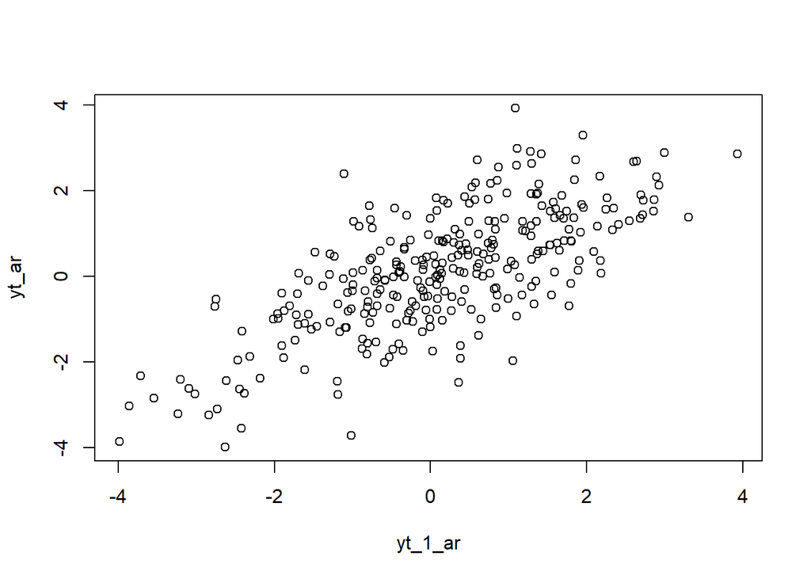

```r
plot(y=yt_ar,x=yt_1_ar)
```

```r
cor(yt_ar,yt_1_ar)
```

```
## [1] 0.7161028
```

```r
yt_ar2 <- ar[-c(1,2)]
yt_ar2
```

```
##   [1] -1.5670108246 -0.8794551485 -1.6890783403  0.0818673463 -0.7724750738
##   [6] -1.0793041051 -1.1954051279 -2.4426568541 -2.6280287147 -3.9825853771
##  [11] -3.8578916236 -3.0197567460 -2.7473542381 -0.5281322030 -1.8821796728
##  [16] -1.9020809107 -1.6080993919 -2.1788059544 -2.3795371734 -2.7328479702
##  [21] -3.0943173054 -2.6175563658 -2.4244916012 -3.5417883306 -2.8378684102
##  [26] -3.2361814957 -3.2006264394 -2.4098590424 -1.2819989901  0.5248461693
##  [31] -0.7673301373  1.3272137941 -0.6476676781  0.5981973841  2.7185562271
##  [36]  1.4441572006  0.5961562661  0.5793048174  2.1859681101  0.0702372818
##  [41]  1.8401394423  2.2636819683  1.8363416698  1.3778000670  0.6006996293
##  [46]  0.2093858952  0.8731194410  2.5487077608  1.2955793561 -0.2331697165
##  [51] -0.5810507641 -0.0788975632 -0.4727180494 -0.4299284950 -0.4795019342
##  [56] -1.6980385520 -1.1187068333 -0.0487288699  0.4495029101  0.7650030321
##  [61]  0.0696701226 -0.0037581027 -1.1824729064 -0.6451468925 -0.3038720265
##  [66]  1.4249986155  1.6532381548  0.6160353575  0.9942156067 -0.5142931687
##  [71]  0.8199001639  1.2800082016  2.9251012390  2.1330757942  1.1768396714
```

[output cut: 45 more lines]

```r
yt_2_ar <- ar[-c(199,200)]
yt_2_ar
```

```
##   [1] -1.7066325607 -0.4040571790 -1.5670108246 -0.8794551485 -1.6890783403
##   [6]  0.0818673463 -0.7724750738 -1.0793041051 -1.1954051279 -2.4426568541
##  [11] -2.6280287147 -3.9825853771 -3.8578916236 -3.0197567460 -2.7473542381
##  [16] -0.5281322030 -1.8821796728 -1.9020809107 -1.6080993919 -2.1788059544
##  [21] -2.3795371734 -2.7328479702 -3.0943173054 -2.6175563658 -2.4244916012
##  [26] -3.5417883306 -2.8378684102 -3.2361814957 -3.2006264394 -2.4098590424
##  [31] -1.2819989901  0.5248461693 -0.7673301373  1.3272137941 -0.6476676781
##  [36]  0.5981973841  2.7185562271  1.4441572006  0.5961562661  0.5793048174
##  [41]  2.1859681101  0.0702372818  1.8401394423  2.2636819683  1.8363416698
##  [46]  1.3778000670  0.6006996293  0.2093858952  0.8731194410  2.5487077608
##  [51]  1.2955793561 -0.2331697165 -0.5810507641 -0.0788975632 -0.4727180494
##  [56] -0.4299284950 -0.4795019342 -1.6980385520 -1.1187068333 -0.0487288699
##  [61]  0.4495029101  0.7650030321  0.0696701226 -0.0037581027 -1.1824729064
##  [66] -0.6451468925 -0.3038720265  1.4249986155  1.6532381548  0.6160353575
##  [71]  0.9942156067 -0.5142931687  0.8199001639  1.2800082016  2.9251012390
```

[output cut: 45 more lines]

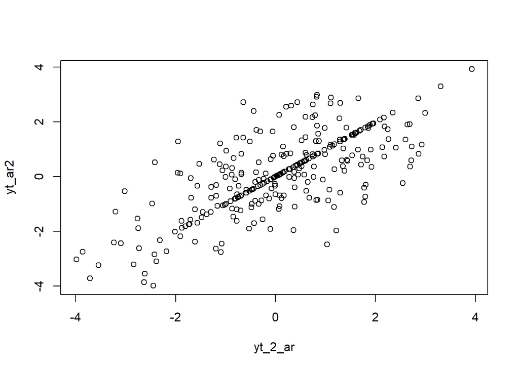

```r
plot(y=yt_ar2,x=yt_2_ar)
```

```r
cor(yt_ar2,yt_2_ar)
```

```
## [1] 0.7085314
```

Secara teoritis, nilai autokorelasi ($\rho_k$) untuk proses $AR(2)$ diperoleh melalui persamaan Yule-Walker:

$$\rho_1 = \frac{\phi_1}{1 -
\phi_2}$$

$$\rho_k = \phi_1 \rho_{k-1} + \phi_2
\rho_{k-2} \quad \text{untuk } k \ge 2$$

Dengan substitusi nilai parameter $\phi_1 = 0.5$ dan $\phi_2 = 0.2$:

$$\rho_1 = \frac{0.5}{1 - 0.2} =
\frac{0.5}{0.8} = 0.625$$

$$\rho_2 = 0.5(0.625) + 0.2(1) = 0.3125 +
0.2 = 0.5125$$

$$\rho_3 = 0.5(0.5125) + 0.2(0.625) =
0.25625 + 0.125 = 0.38125$$

# Proses ARMA(2,2)

- Bangkitkan model ARMA(2,2) dengan 𝜃1 = 0.4, 𝜃2 = 0.6 ,𝜙1 = 0.5 dan 𝜙2 = 0.2 sebanyak 300 data (Manual dan arima.sim)
- Buat plot time series, plot ACF, plot PACF dan plot EACF. Idenifikasi apakah data tersebut stasioner
- Buat scatterplot antara 𝑌𝑡 dengan 𝑌𝑡−1, 𝑌𝑡 dengan 𝑌𝑡−2 serta 𝑌𝑡 dengan 𝑌𝑡−3
- Hitung autokorelasi masing masing baik dari data bangkitan maupun secara teoriti

## Bangkitkan dengan arima.sim

```r
set.seed(1234)
arma.sim <- arima.sim(list(order = c(2, 0, 2),
                             ar = c(0.5, 0.2),
                             ma = c(0.4, 0.6)), n = 300)
arma.sim
```

```
## Time Series:
## Start = 1
## End = 300
## Frequency = 1
##   [1] -2.75189059 -1.74814288 -2.98064692 -1.12111691 -1.75293106 -1.33898765
##   [7] -2.09046996 -3.56829323 -4.32225209 -6.49932813 -7.02769509 -6.95242810
##  [13] -6.26996407 -3.43890672 -3.74182891 -2.97181976 -3.49823015 -3.96328709
##  [19] -4.21591372 -4.99194225 -5.61517562 -5.49498965 -5.32810268 -6.08211738
##  [25] -5.70927763 -6.49640104 -6.19781946 -5.63181804 -4.16631811 -1.43386858
##  [31] -1.32659085  1.33518960 -0.57718012  1.13545868  2.56923465  2.89049818
##  [37]  2.80495292  1.68426168  2.77538382  1.29220743  3.17981524  3.04188012
##  [43]  3.84589813  3.47054592  2.25362466  1.27634579  1.31729358  3.02358708
##  [49]  2.83893413  1.81428668  0.10302896 -0.45121970 -0.85290753 -0.66635425
##  [55] -0.93510416 -2.14779642 -2.08562341 -1.51503473 -0.24121274  0.91556687
##  [61]  0.64537308  0.48311177 -1.14217407 -1.12039092 -1.27141453  0.91636167
```

[output cut: 39 more lines]

## Plot time series

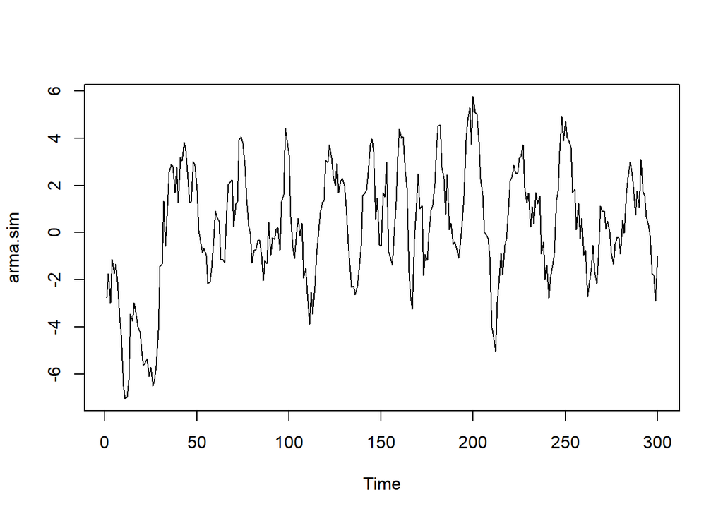

```r
ts.plot(arma.sim)
```

## Plot ACF

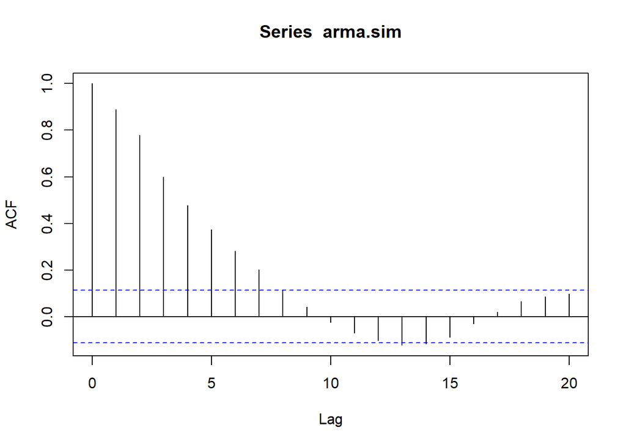

```r
acf(arma.sim, lag.max = 20)
```

## Plot PACF

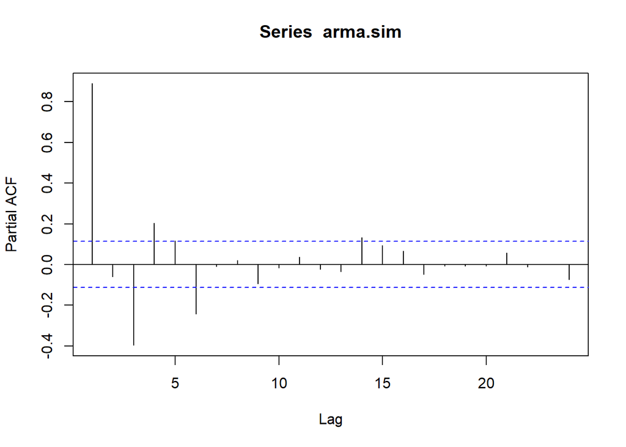

```r
pacf(arma.sim)
```

## Plot EACF

```r
TSA::eacf(arma.sim)
```

```
## AR/MA
##   0 1 2 3 4 5 6 7 8 9 10 11 12 13
## 0 x x x x x x x o o o o  o  x  o
## 1 o x o o o o x o o o o  o  o  o
## 2 x x o o o o o o o o o  o  o  o
## 3 x x x x o o o o o o o  o  o  o
## 4 x x x x o o o o o o o  o  o  o
## 5 x x x x x x x o o o o  o  o  o
## 6 o o x o x x o o o o o  o  o  o
## 7 x o x x x x o x o o o  o  o  o
```

## Scatterplot dan korelasi lag 1 (Y_t dengan Y_{t-1})

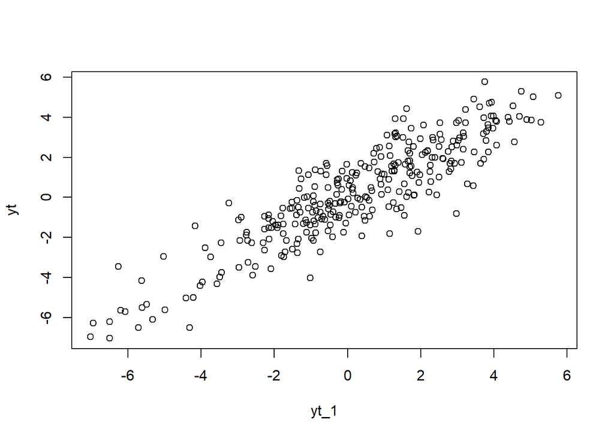

```r
yt <- arma.sim[-1]
yt_1 <- arma.sim[-300]

plot(y = yt, x = yt_1)
```

```r
cor(yt, yt_1)
```

```
## [1] 0.8918177
```

## Scatterplot dan korelasi lag 2 (Y_t dengan Y_{t-2})

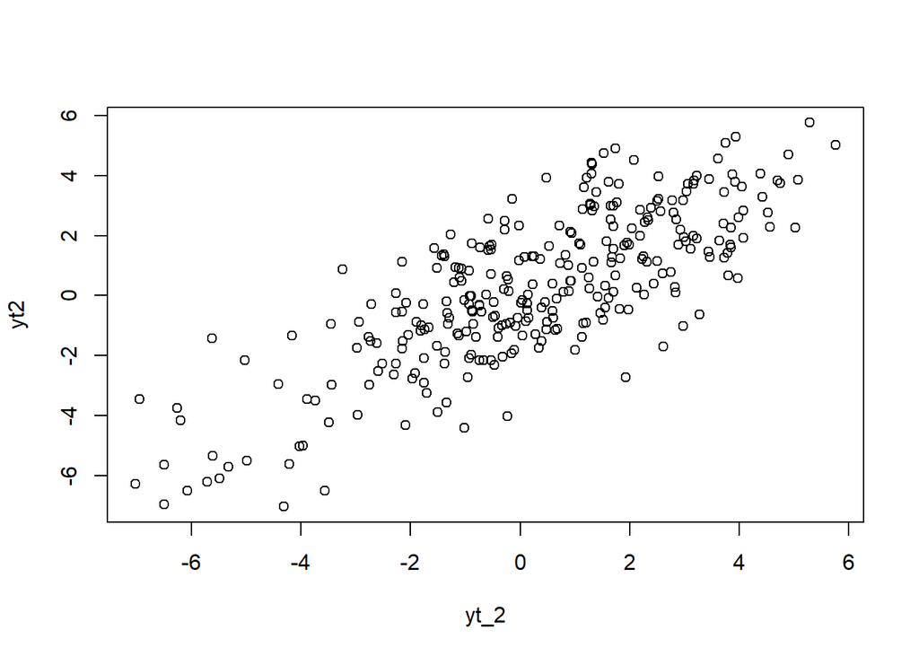

```r
yt2 <- arma.sim[-c(1, 2)]
yt_2 <- arma.sim[-c(299, 300)]

plot(y = yt2, x = yt_2)
```

```r
cor(yt2, yt_2)
```

```
## [1] 0.7836583
```

## Scatterplot dan korelasi lag 3 (Y_t dengan Y_{t-3})

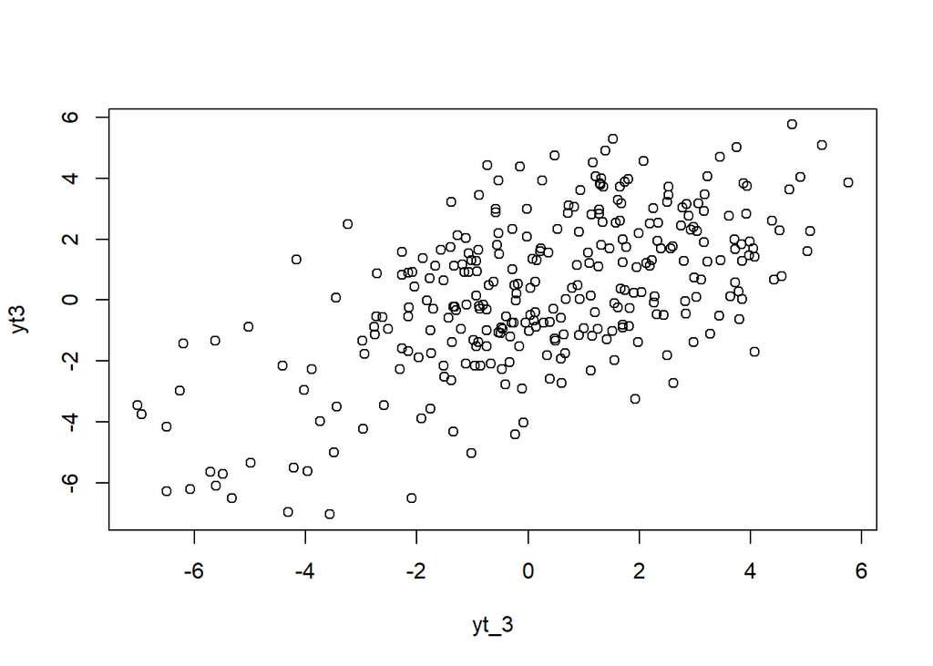

```r
yt3 <- arma.sim[-c(1, 2, 3)]
yt_3 <- arma.sim[-c(298, 299, 300)]

plot(y = yt3, x = yt_3)
```

```r
cor(yt3, yt_3)
```

```
## [1] 0.6044325
```

## Autokorelasi secara teoritis

```r
ARMAacf(ar = c(0.5, 0.2), ma = c(0.4, 0.6), lag.max = 3)
```

```
##         0         1         2         3
## 1.0000000 0.8591993 0.7491908 0.5464353
```

$$\rho_k = \phi_1 \rho_{k-1} + \phi_2
\rho_{k-2}$$

Dengan substitusi nilai parameter $\phi_1 = 0.5$ dan $\phi_2 = 0.2$:

$$\rho_k = 0.5 \rho_{k-1} + 0.2
\rho_{k-2}$$

Perhitungan nilai untuk lag 1 hingga lag 3 dilakukan menggunakan fungsi `ARMAacf()` pada R:

Nilai autokorelasi dari hasil simulasi data (`cor()`) mendekati perhitungan nilai teoritis tersebut.